# Homework One

Yi Chen(yc3356)

January 27, 2018

# Homework One

## problem one

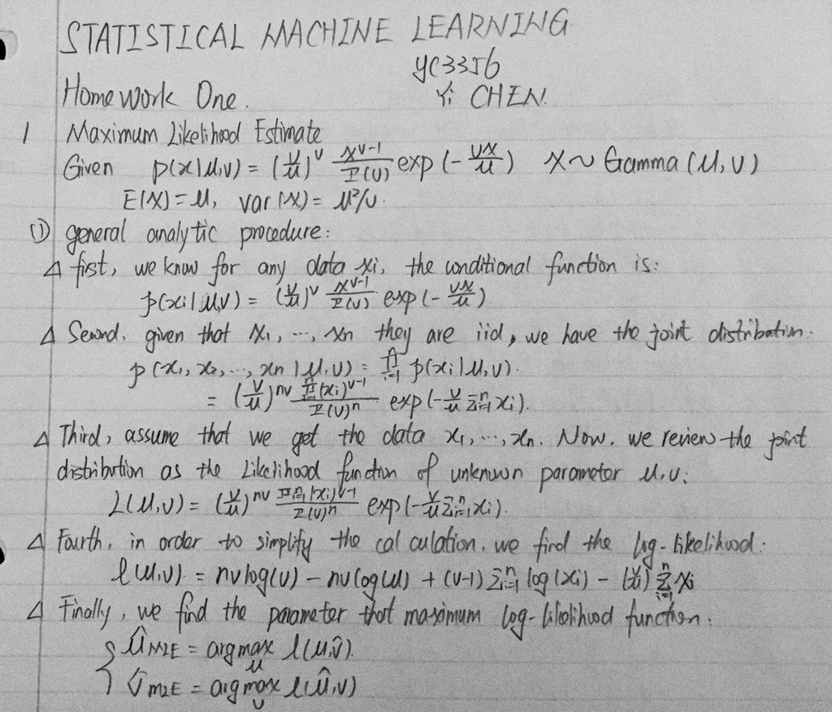

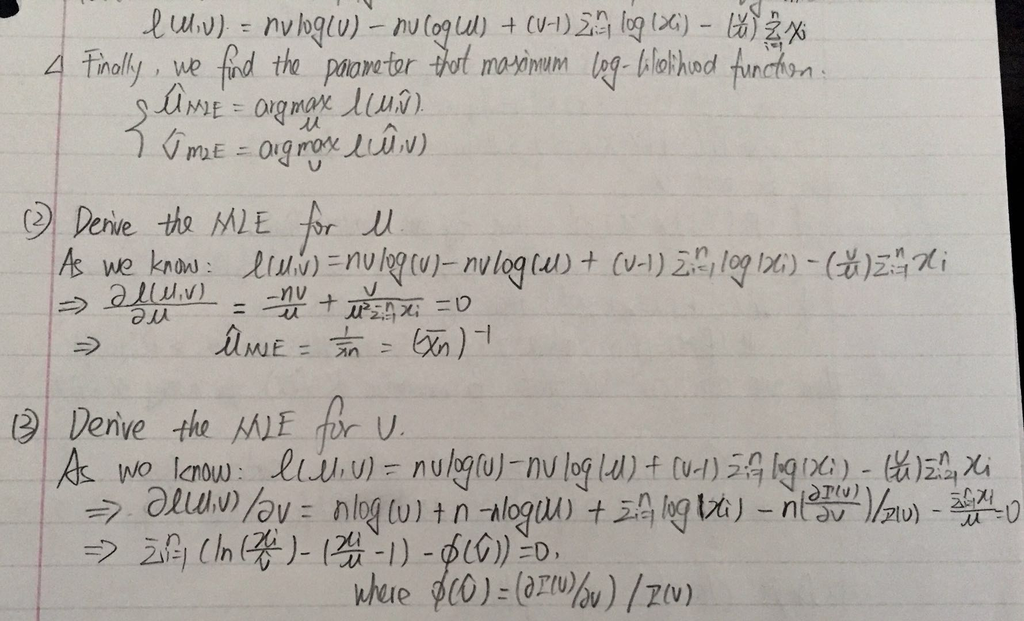

## problem two

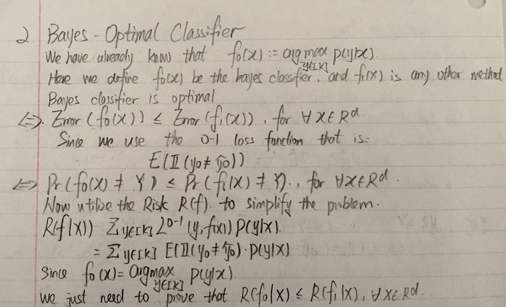

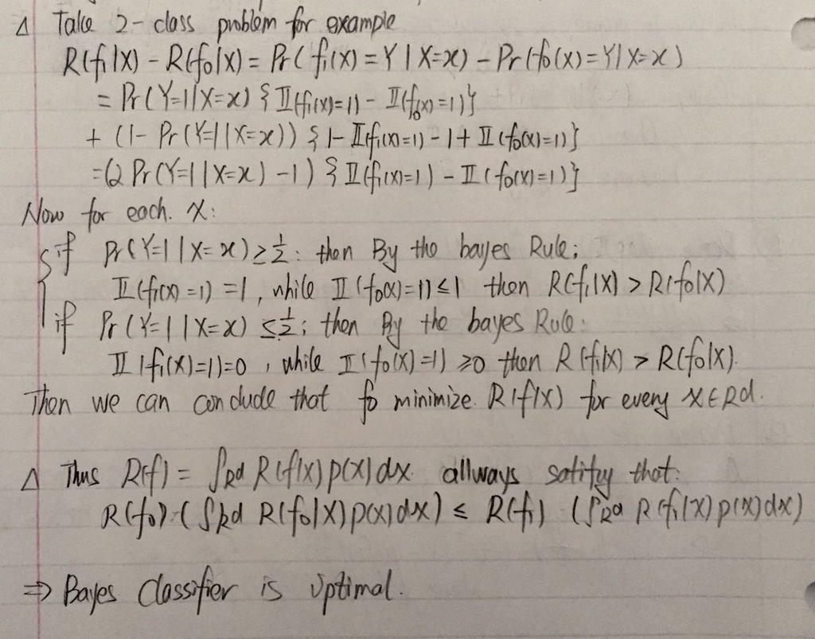

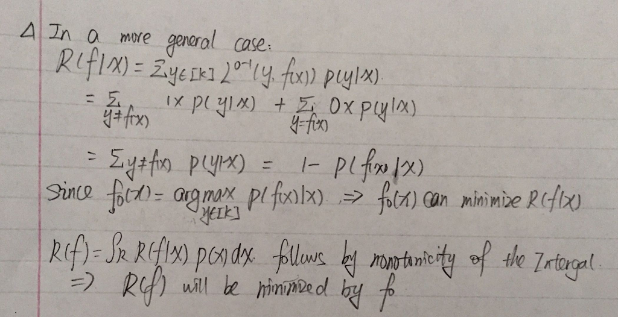

## problem three

1. load the data. I actually download the csv file from the yahoo finance after searching the stock information about apple.

```r
setwd("C:/Users/cheny/Desktop/study/second term/staistical machine learning/homework/homework one")
data <- read.csv('data.csv')
data <- data[1:30]
```

2. preform a PCA on the closing price and create the biplot

```r
PCA_1 <- princomp(data,cor = FALSE)
summary(PCA_1)
```

```
## Importance of components:
##                            Comp.1      Comp.2      Comp.3      Comp.4
## Standard deviation     60.8802452 16.19707406 10.30672945 6.182315151
## Proportion of Variance  0.8750937  0.06194053  0.02508092 0.009024104
## Cumulative Proportion   0.8750937  0.93703427  0.96211520 0.971139302
##                             Comp.5      Comp.6      Comp.7      Comp.8
## Standard deviation     5.429506015 4.519191051 4.408387623 3.925346257
## Proportion of Variance 0.006960211 0.004821955 0.004588401 0.003637958
## Cumulative Proportion  0.978099513 0.982921469 0.987509869 0.991147828
##                             Comp.9     Comp.10     Comp.11      Comp.12
## Standard deviation     2.814530660 2.622373962 2.254459451 1.7810330193
## Proportion of Variance 0.001870311 0.001623645 0.001200015 0.0007489378
## Cumulative Proportion  0.993018139 0.994641783 0.995841798 0.9965907361
##                             Comp.13      Comp.14      Comp.15      Comp.16
## Standard deviation     1.4786948667 1.4001826592 1.3081532756 1.2587103966
## Proportion of Variance 0.0005162486 0.0004628829 0.0004040351 0.0003740705
## Cumulative Proportion  0.9971069848 0.9975698677 0.9979739028 0.9983479733
##                            Comp.17      Comp.18      Comp.19      Comp.20
## Standard deviation     1.151802557 1.0465861114 0.9901122467 0.9015490154
## Proportion of Variance 0.000313226 0.0002586138 0.0002314572 0.0001919024
## Cumulative Proportion  0.998661199 0.9989198131 0.9991512703 0.9993431727
##                             Comp.21      Comp.22      Comp.23      Comp.24
## Standard deviation     0.7924427595 0.6996034172 6.086937e-01 5.267060e-01
## Proportion of Variance 0.0001482646 0.0001155595 8.747812e-05 6.549956e-05
## Cumulative Proportion  0.9994914374 0.9996069969 9.996945e-01 9.997600e-01
##                             Comp.25      Comp.26      Comp.27      Comp.28
## Standard deviation     5.010247e-01 4.860420e-01 4.725970e-01 3.739478e-01
## Proportion of Variance 5.926798e-05 5.577626e-05 5.273316e-05 3.301596e-05
## Cumulative Proportion  9.998192e-01 9.998750e-01 9.999278e-01 9.999608e-01
##                             Comp.29      Comp.30
## Standard deviation     0.3130792461 2.610486e-01
## Proportion of Variance 0.0000231425 1.608958e-05
## Cumulative Proportion  0.9999839104 1.000000e+00
```

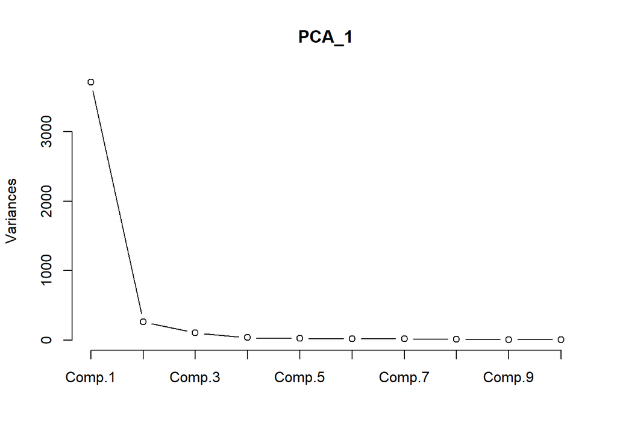

```r
screeplot(PCA_1,type = 'lines')
```

# only one componenet is enough

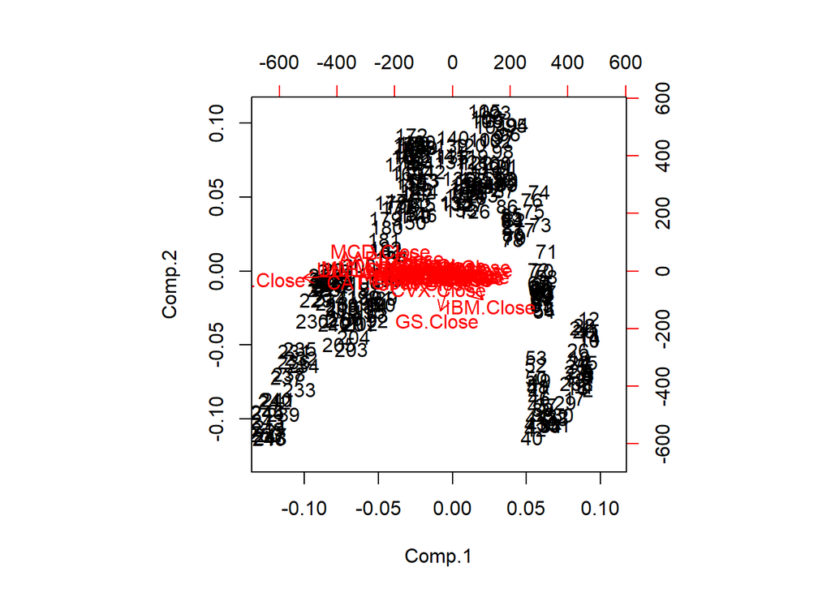

```r
biplot(PCA_1)
```

**analysis**

As we can see in the biplot, the first component explain almost all the variance of the data. Thus, we can see the arrows are almost all left or right direction. But the second component only have every little proportion of variance. Thus, in the up and down direction, the difference is very small. And as we can see from the screen plot, the first component count over 80% of the variance. This tells us that their is only one component. For thoes company have long arrows is because the price of their stock is relatively high. Thus, the componenet have relative bigger inference on them. And the reason for many companies have the same direction is that maybe these companies are somekind of similar with each other.

```r
PCA_2 <- princomp(x = data,cor = TRUE)
summary(PCA_2)
```

```
## Importance of components:
##                           Comp.1    Comp.2     Comp.3    Comp.4    Comp.5
## Standard deviation     4.3703573 2.0993331 1.37312336 1.2536494 0.8456737
## Proportion of Variance 0.6366674 0.1469067 0.06284893 0.0523879 0.0238388
## Cumulative Proportion  0.6366674 0.7835741 0.84642301 0.8988109 0.9226497
##                            Comp.6     Comp.7      Comp.8      Comp.9
## Standard deviation     0.76734140 0.71208084 0.509952718 0.455750555
## Proportion of Variance 0.01962709 0.01690197 0.008668392 0.006923619
## Cumulative Proportion  0.94227680 0.95917877 0.967847163 0.974770782
##                            Comp.10    Comp.11     Comp.12    Comp.13
## Standard deviation     0.390450292 0.32975718 0.305314860 0.26345908
## Proportion of Variance 0.005081714 0.00362466 0.003107239 0.00231369
## Cumulative Proportion  0.979852496 0.98347716 0.986584395 0.98889808
##                            Comp.14     Comp.15    Comp.16     Comp.17
## Standard deviation     0.248702454 0.213761136 0.20372338 0.182097341
## Proportion of Variance 0.002061764 0.001523127 0.00138344 0.001105315
## Cumulative Proportion  0.990959848 0.992482975 0.99386642 0.994971731
##                             Comp.18      Comp.19     Comp.20      Comp.21
## Standard deviation     0.1645551987 0.1499179959 0.136089164 0.1319911221
## Proportion of Variance 0.0009026138 0.0007491802 0.000617342 0.0005807219
## Cumulative Proportion  0.9958743444 0.9966235245 0.997240867 0.9978215884
##                             Comp.22      Comp.23      Comp.24      Comp.25
## Standard deviation     0.1117890724 0.1099294594 0.0987842582 0.0892323070
## Proportion of Variance 0.0004165599 0.0004028162 0.0003252777 0.0002654135
## Cumulative Proportion  0.9982381483 0.9986409645 0.9989662422 0.9992316557
##                            Comp.26      Comp.27      Comp.28      Comp.29
## Standard deviation     0.076795511 0.0747914892 0.0703162395 0.0592271652
## Proportion of Variance 0.000196585 0.0001864589 0.0001648125 0.0001169286
## Cumulative Proportion  0.999428241 0.9996146996 0.9997795120 0.9998964406
##                             Comp.30
## Standard deviation     0.0557385129
## Proportion of Variance 0.0001035594
## Cumulative Proportion  1.0000000000
```

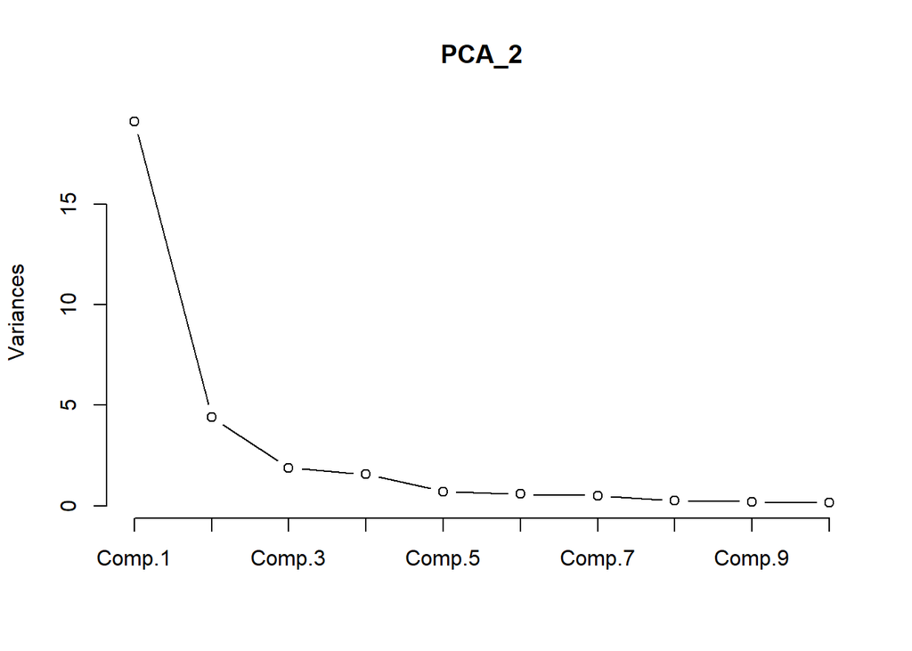

```r
screeplot(PCA_2,type = 'lines')
```

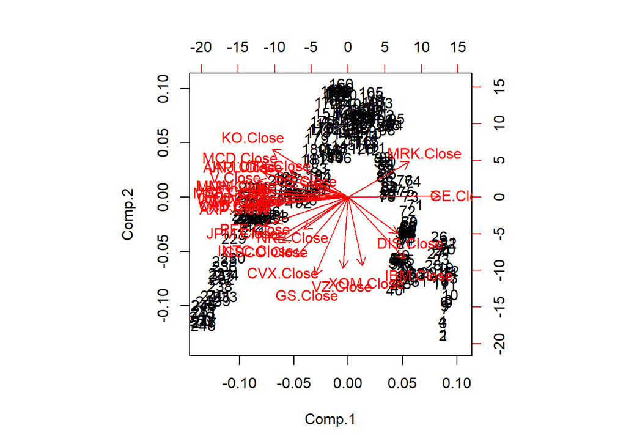

```r
biplot(PCA_2,scale = 1)
```

**analysis** After we calculate the z-socre of every data( after standardization), we treat all the data equally and ignore the scale of the data. In the first plot, the difference in the scale is so big that make other difference relatively lss important. But now, since we have exclude the impact of scale difference, we can see the influence of other factors more easily. Thus, we can see the data’s difference are more obvious. The company will have different direction.

```r
data2 <- read.csv('data2.csv')
PCA_3 <- princomp(x = data2,cor = TRUE)
summary(PCA_3)
```

```
## Importance of components:
##                           Comp.1     Comp.2    Comp.3     Comp.4
## Standard deviation     2.3406648 1.60700833 1.3928274 1.27944610
## Proportion of Variance 0.1826237 0.08608253 0.0646656 0.05456608
## Cumulative Proportion  0.1826237 0.26870624 0.3333718 0.38793793
##                            Comp.5     Comp.6     Comp.7     Comp.8
## Standard deviation     1.21300184 1.13331794 1.06039891 1.02433758
## Proportion of Variance 0.04904578 0.04281365 0.03748153 0.03497558
## Cumulative Proportion  0.43698371 0.47979736 0.51727889 0.55225447
##                            Comp.9   Comp.10    Comp.11    Comp.12
## Standard deviation     1.01205536 0.9779908 0.95094763 0.94391499
## Proportion of Variance 0.03414187 0.0318822 0.03014338 0.02969918
## Cumulative Proportion  0.58639634 0.6182785 0.64842192 0.67812110
##                           Comp.13    Comp.14    Comp.15    Comp.16
## Standard deviation     0.90104653 0.89603360 0.86234333 0.84320697
## Proportion of Variance 0.02706283 0.02676254 0.02478787 0.02369993
## Cumulative Proportion  0.70518393 0.73194647 0.75673434 0.78043427
##                           Comp.17   Comp.18    Comp.19    Comp.20
## Standard deviation     0.82414017 0.7882260 0.77743457 0.76184302
## Proportion of Variance 0.02264023 0.0207100 0.02014682 0.01934683
## Cumulative Proportion  0.80307451 0.8237845 0.84393133 0.86327816
##                          Comp.21    Comp.22    Comp.23    Comp.24
## Standard deviation     0.7468614 0.73348499 0.71545086 0.70360694
## Proportion of Variance 0.0185934 0.01793334 0.01706233 0.01650209
## Cumulative Proportion  0.8818716 0.89980490 0.91686723 0.93336932
##                           Comp.25   Comp.26    Comp.27    Comp.28
## Standard deviation     0.67333710 0.6155509 0.60718749 0.58393666
## Proportion of Variance 0.01511276 0.0126301 0.01228922 0.01136607
## Cumulative Proportion  0.94848208 0.9611122 0.97340140 0.98476746
##                            Comp.29     Comp.30
## Standard deviation     0.536360893 0.411452359
## Proportion of Variance 0.009589434 0.005643101
## Cumulative Proportion  0.994356899 1.000000000
```

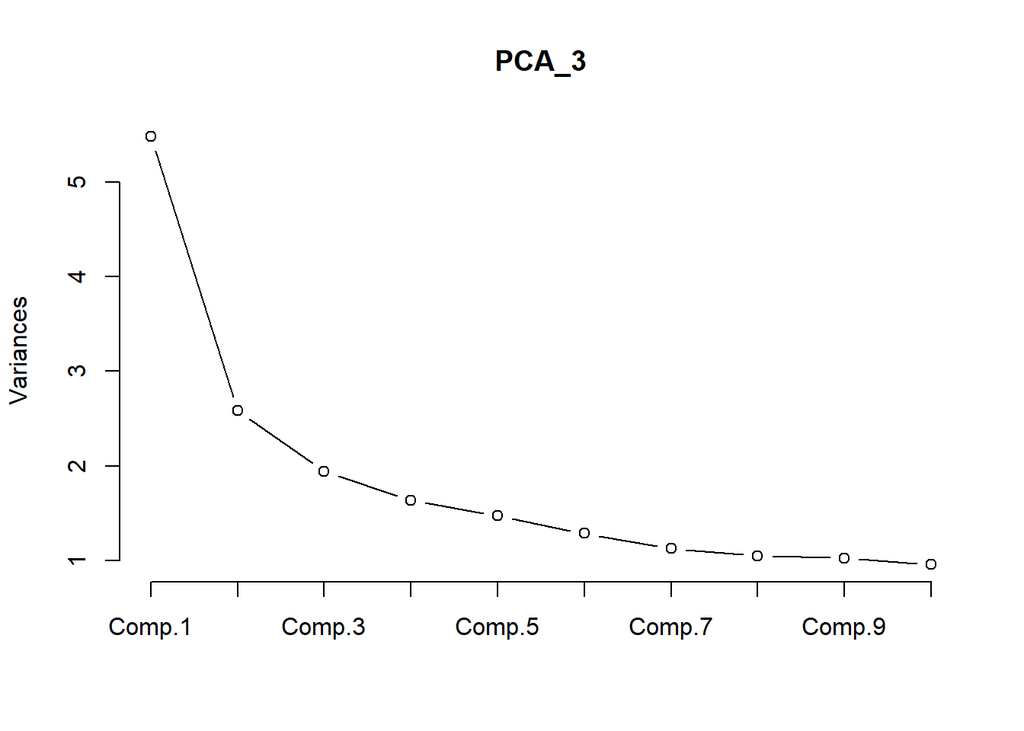

```r
screeplot(PCA_3,type = 'lines')
```

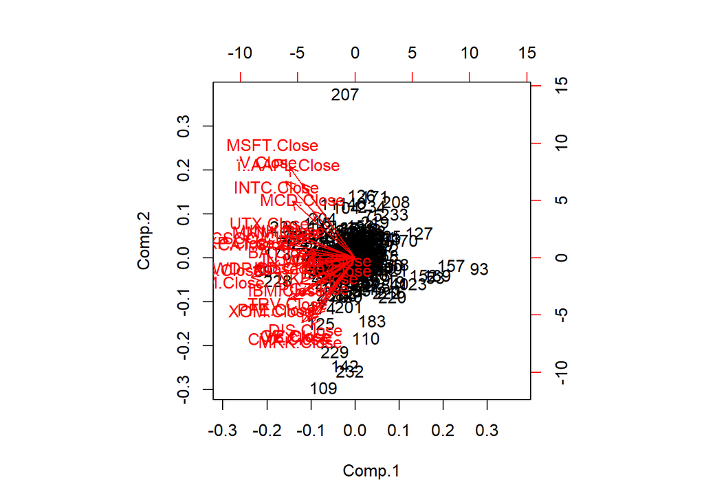

```r
biplot(PCA_3,scale = 1)
```